# Generalized Linear/Additive Mixed-Effect Models (GLMMs)

“YOUR NAME HERE”

2022-10-03

# **The Set-up**

## *Learning objectives.*

1. Implement as Generalized Linear/Additive Mixed-Effect Models model that considers the spatial structure in the Data `R`.
2. Determine the fit of a Generalized Linear/Additive Mixed-Effect Models.
3. Reduce a Generalized Linear/Additive Mixed-Effect Model to the minimum adequate number of predictors using a stepwise procedure.

## *Before you start*

The practical will be run using *RStudio cloud* to avoid individual machine troubleshooting. This means you **need** to have an account for *RStudio cloud*.

However, remember to have [`R`](https://cran.r-project.org) and [R-studio](http://www.rstudio.com/) in your/room computer so you can work on the project after class.

**You should have also** 1. Read chapter 5 and 13 of Zuur mixed effect models book. 1. Read chapter 19 of Crawley the R book. 2. Done the Tutorial for this week.

## *The way it’s going to be run*

In this 3h practical you will to implement what you have learned in the class about Regression Analyses in `R`.

You will be building and **R-Markdown** document during the class. **R-Markdown** documents allows you to combine your code, its results, and your prose commentary into a single document. If you manage to produce a document your code works. The resulting file (a html) is what you will hand-in at the end of the practical.

The final document will have three classes of boxes

The text in the blue filled box marked as **Your task** states what you need to do

```r
#
# The code in the window marked like this shows where you need to write your code
#
```

The text in the green filled box marked as **Question** phrases a question, and where you will place the answer to the **question** is marked as ***PLACE YOUR ANSWER HERE**.

## About the data you will use.

The data to be used in this week practical is a combination of the biodiversity data from the [Biowide](https://ecos.au.dk/forskningraadgivning/temasider/biowide) project, which aimed at collecting biodiversity data from 130 terrestrial sampling sites across Denmark. The dataset contains data for Plants (vascular plants and bryophytes), fungi (lichens and macrofungi), gastropods, and arthropods. You can get the [biodiversity data](https://www.gbif.org/dataset/cd4eb3ec-0a18-42b4-bda4-155716ddd7b1#description) from the Danish Biodiversity Information Facility. For further information on the project check the publication.

Although environmental variables were collected as part of Biowide, this data is not available for our use. The data on environmental variables included in the table you will use comes from multiple Geospatial datasets I complied for this course.

Here you will focus on the flowing variables:

**1) decimalLongitude**: East-West position in decimal-degrees of a sample site coming from [Biowide](https://ecos.au.dk/forskningraadgivning/temasider/biowide).

**2) decimalLatitude**: North-South position in decimal-degrees of a sample site coming from [Biowide](https://ecos.au.dk/forskningraadgivning/temasider/biowide).

**3) Log.S.AllGrp**: The total species richness of a sample site (sum of the unique species of all sampled groups in a site) coming from [Biowide](https://ecos.au.dk/forskningraadgivning/temasider/biowide).

**4) AgrBasMp**: Density of agricultural land cover types as defined by [BASEMAP](https://envs.au.dk/en/research-areas/society-environment-and-resources/land-use-and-gis/basemap).

**5) WetLndBasMp**: Density of Wetlands cover types as defined by [BASEMAP](https://envs.au.dk/en/research-areas/society-environment-and-resources/land-use-and-gis/basemap).

**6) Slope30mAgg**: the maximum rate of change in value from that cell to its neighbours estimated based on the [SRTM-30m DEM](https://www2.jpl.nasa.gov/srtm/).

**7) NDVI**: Normalized difference vegetation index, a simple graphical indicator that can be used to analyse vegetation greenness and has strong relation with productivity [Copernicus Global Land Service](https://land.copernicus.eu/global/products/ndvi).

**8) Mean Annual Temperature (MAT)**: Annual average of temperatures coming the [CHELSA-climatologies](https://chelsa-climate.org) ..

**9) Dis2Cost**: Distance in km of a sampled site to the coast estimated by me using Denmark high resolution contour map coming form the Database of Global Administrative Areas [GADAM](https://gadm.org).

**10) HII**: [Human Influence Index](https://sedac.ciesin.columbia.edu/data/set/wildareas-v2-human-influence-index-geographic), a measurement of the anthropogenic impacts on the environment.

**11) PrecSea**: Seasonality of precipitation measured as the variability of monthly values (using the CV) coming the [CHELSA-climatologies](https://chelsa-climate.org).

## 1) The first step: Loading the data

**Your task:**

Use `read.csv` to load the file - The file is comma-separated

Save the object as an object named `DK.Biodiv`.

```r
# Read the file and save it as an object named `DK.Biodiv`
DK.Biodiv <- read.csv("data/Biowide_With_EnvDta.csv", # file name
                      stringsAsFactors = TRUE # Make the categorical variables Factors
                      )
# Use the function head to print the five first rows
head(DK.Biodiv)
```

```
##   X.1 X ID decimalLongitude decimalLatitude S.AllGrp S.Arthropoda
## 1   3 3  3         10.08032        57.58100      227          140
## 2   4 4  4         10.21615        56.93747      296          101
## 3   5 5  5         10.22988        56.93213      337          118
## 4   6 6  6         10.24092        57.59655      195           83
## 5   7 7  7         10.24669        55.12991      366          167
## 6   8 8  8         10.24766        55.12293      345          125
##   S.Spermatophyte S.Magnoliophyta   landsdele              Geology NatDensBasMp
## 1              48              48 Nordjylland         Aeolian sand    0.8293574
## 2              25              25 Nordjylland Marine sand and clay    0.6634633
## 3              40              40 Nordjylland         Beach ridges    0.9818926
## 4              11               7 Nordjylland         Aeolian sand    0.9593000
## 5              84              84  Syddanmark        Glaciofluvial    0.6070855
## 6              49              47  Syddanmark        Glaciofluvial    0.8152910
##   OpnNatBasMp ForDenBasMp    AgrBasMp WetLndBasMp Dis2Cost      HII Slope30mAgg
```

[output cut: 20 more lines]

## 2) Building a regression.

**Your task:**

Use the function `glm()` to build model with only *ONE* **continuous** predictor. Here, **DO NOT** use either `decimalLongitude` and `decimalLatitude` as predictors. **Remember** to include the adequate `family`for the class of `S.AllGrp`.

```r
DK.Biodiv.lm <- glm(S.AllGrp ~ Slope30mAgg, #  select only ONE continuous** predictor.
                    data = DK.Biodiv, # data frame with the data
                    family = "poisson") # Error distribution
# Print the summary of DK.Biodiv.lm
summary(DK.Biodiv.lm)
```

```
##
## Call:
## glm(formula = S.AllGrp ~ Slope30mAgg, family = "poisson", data = DK.Biodiv)
##
## Deviance Residuals:
##      Min        1Q    Median        3Q       Max
## -10.0147   -3.4236   -0.2825    2.9380    9.9116
##
## Coefficients:
##             Estimate Std. Error z value Pr(>|z|)
## (Intercept) 5.459854   0.012513  436.33   <2e-16 ***
## Slope30mAgg 0.046137   0.003137   14.71   <2e-16 ***
## ---
## Signif. codes:  0 '***' 0.001 '**' 0.01 '*' 0.05 '.' 0.1 ' ' 1
##
## (Dispersion parameter for poisson family taken to be 1)
##
##     Null deviance: 2379.7  on 103  degrees of freedom
## Residual deviance: 2168.7  on 102  degrees of freedom
## AIC: 2943.6
##
## Number of Fisher Scoring iterations: 4
```

## 3) Check your regression.

**Your task:**

- Evaluate graphically the assumptions of your reduced linear model (`DK.Biodiv.lm`).

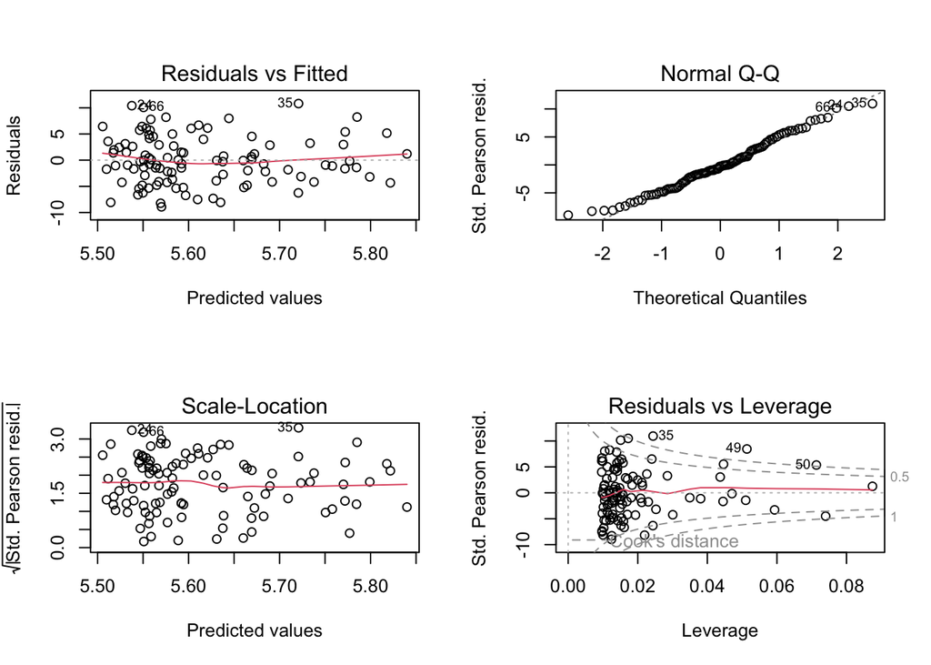

```r
# define a 2x2 plotting space
par(mfrow=c(2,2))
# Evaluate graphically the assumptions of your reduced linear model
plot(DK.Biodiv.lm)
```

**Question:** Are the following assumptions meet??

**Your task:**

- Using a box-plot, evaluate if there is homogeneity if variances between sites sampled on different regions. For this, you will:
  1. Extract the *Deviance* residuals from `DK.Biodiv.lm`, saving these as an object named `DK.Biodiv.lm.Res`. Remember to define the Type of residuals you would like to extract.
  2. Plot the residuals by region (`landsdele`).

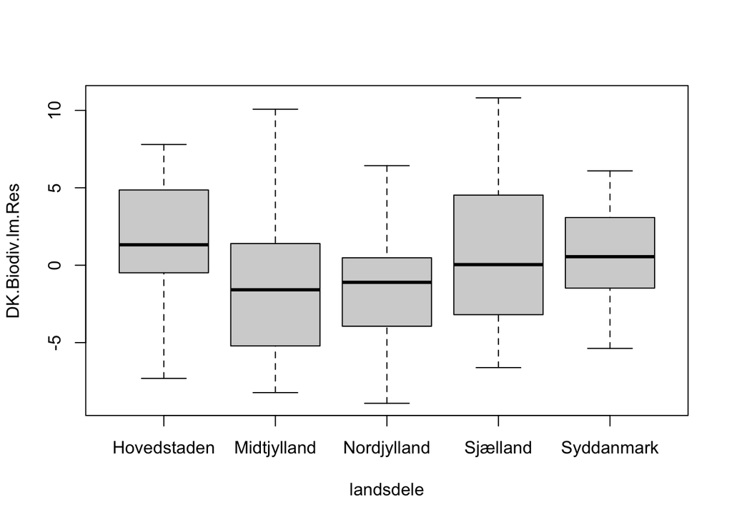

```r
# Extract the *Deviance* residuals
DK.Biodiv.lm.Res <- residuals(object = DK.Biodiv.lm, # The regression
                              type = "pearson" # the type of residuals which should be returned
                              )
# Plot the residuals by region
boxplot(DK.Biodiv.lm.Res~landsdele,
        data = DK.Biodiv)
```

**Question:** Is there Homogeneity of variances across regions?.

No, The average and variability of the residuals differers between regions.

## 4) Setting the Scene for the mixed effect Random intercept model

**Your task:**

Use the function `glm()` to build model with the predictor you selected in `DK.Biodiv.lm` AND `landsdele`, as a predictor. Here add the categorical predictors as additive term. **Remember** to include the adequate `family`for the class of `S.AllGrp`.

```r
DK.Biodiv.lm2 <- glm(S.AllGrp ~ Slope30mAgg + landsdele, #  the Equations defining the response and additive combination of predictors
                    data = DK.Biodiv,
                    family = "poisson")
# Print the summary of DK.Biodiv.lm2
summary(DK.Biodiv.lm2)
```

```
##
## Call:
## glm(formula = S.AllGrp ~ Slope30mAgg + landsdele, family = "poisson",
##     data = DK.Biodiv)
##
## Deviance Residuals:
##     Min       1Q   Median       3Q      Max
## -9.3108  -3.1800  -0.4781   2.4974  10.4411
##
## Coefficients:
##                       Estimate Std. Error z value Pr(>|z|)
## (Intercept)           5.534436   0.022827 242.447  < 2e-16 ***
## Slope30mAgg           0.049315   0.003268  15.089  < 2e-16 ***
## landsdeleMidtjylland -0.150848   0.024171  -6.241 4.35e-10 ***
## landsdeleNordjylland -0.159327   0.024817  -6.420 1.36e-10 ***
## landsdeleSjælland    -0.024937   0.023881  -1.044   0.2964
## landsdeleSyddanmark  -0.049113   0.024045  -2.043   0.0411 *
## ---
## Signif. codes:  0 '***' 0.001 '**' 0.01 '*' 0.05 '.' 0.1 ' ' 1
##
## (Dispersion parameter for poisson family taken to be 1)
##
##     Null deviance: 2379.7  on 103  degrees of freedom
## Residual deviance: 2057.7  on  98  degrees of freedom
## AIC: 2840.6
##
## Number of Fisher Scoring iterations: 4
```

**Question:** how much has the Model performance improved (i.e., **deviance explained**) by adding the categorical term?.

The model with the categorical term now explains ~13% of the deviance while one with out it explains only `8%

**Question:** how much has adding the categorical term costed in terms of degrees of freedom?.

By adding region as a categorical predictor, you lost four (4) degrees of freedom, 1- Number of regions.

## 5) Building a random intercept model

**Your task:**

- Build a Generalized linear Mixed effects model that includes “region”as random intercept. For this, use the function `glmer` of the package `lme4`. Remember that in `lme4`, random effects are added defined as `(1 | X)`, and added as a predictor in your function.

```r
DK.Biodiv.RndInt <- glmer(S.AllGrp ~ Slope30mAgg + (1 | landsdele), #  the Equations defining the response and additive combination of predictors
                         data =DK.Biodiv,
                         family = "poisson")
# Print the summary of DK.Biodiv.RndInt
summary(DK.Biodiv.RndInt)
```

```
## Generalized linear mixed model fit by maximum likelihood (Laplace
##   Approximation) [glmerMod]
##  Family: poisson  ( log )
## Formula: S.AllGrp ~ Slope30mAgg + (1 | landsdele)
##    Data: DK.Biodiv
##
##      AIC      BIC   logLik deviance df.resid
##   2855.3   2863.2  -1424.6   2849.3      101
##
## Scaled residuals:
##     Min      1Q  Median      3Q     Max
## -8.3378 -3.1229 -0.5112  2.5153 11.4961
##
## Random effects:
##  Groups    Name        Variance Std.Dev.
##  landsdele (Intercept) 0.004067 0.06377
## Number of obs: 104, groups:  landsdele, 5
##
## Fixed effects:
##             Estimate Std. Error z value Pr(>|z|)
## (Intercept) 5.457325   0.031310  174.30   <2e-16 ***
## Slope30mAgg 0.049131   0.003264   15.05   <2e-16 ***
## ---
## Signif. codes:  0 '***' 0.001 '**' 0.01 '*' 0.05 '.' 0.1 ' ' 1
##
## Correlation of Fixed Effects:
##             (Intr)
## Slope30mAgg -0.358
```

**Question:** How did the addition of a random intercepts change the parameter estimates in `DK.Biodiv.RndInt` when compared to those in `DK.Biodiv.lm`?.

The parameters and their SE only changed slightly, with the largest change taking place in the Intercept SE.

**Question:** how much has the Model performance improved (i.e., **deviance explained**) when compared to the original model by adding the regions as a random intercept?.

The model with regions as a random intercept explains ~13% of the deviance (the same as the model with it as a categorical predictor) while one with out it explains only `8%

**Question:** how much has adding the categorical term costed in terms of degrees of freedom?.

**Your task:**

- Extract the random intercepts from the `DK.Biodiv.RndInt` model. For this, you will use the function `random.effects` of the package `nlme`.

```r
 # Extract the random intercepts
 random.effects(DK.Biodiv.RndInt)
```

```
## $landsdele
##             (Intercept)
## Hovedstaden  0.07026097
## Midtjylland -0.07047671
## Nordjylland -0.07800457
## Sjælland     0.05120386
## Syddanmark   0.02748455
##
## with conditional variances for "landsdele"
```

**Question:** Make an interpretation of the random intercept extracted in the task above?.

These indicate how much will species richness increase of decrease when the predictors are evaluated at their mean level. Namely, that *Midtjylland* and *Nordjylland* will have a lower overall species richness that other parts of Denmark under the same “average” environmental conditions.

**Your task:**

- Generate a prediction for your random intercept model, taking into consideration the effect of “region”. For this, you will:
  1. Generate a new object to be used for predicting your model. This new object, named `TempPred` will have 100 values between the minimum and maximum of your selected predictor.
  2. Create a new object names `TempPredReg` where the values in `TempPred` are paired to a sequence of 100 times the string name of each region.
  3. Use `DK.Biodiv.RndInt` to generate a prediction for each predictor/region combination in `TempPredReg`.
  4. Append the predicted values to `TempPredReg` as a variable named `S.AllGrp`.

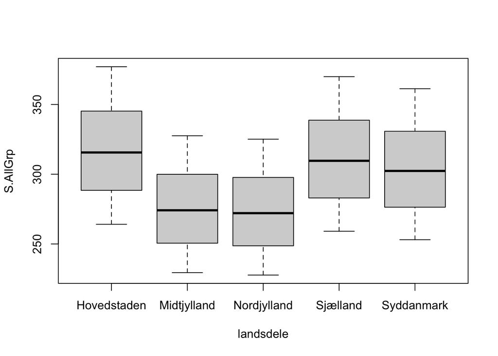

```r
# 1) Generate a new object with sequential values for the predictor.
TempPred <- seq(from = min(DK.Biodiv$Slope30mAgg), # the starting values
                to = max(DK.Biodiv$Slope30mAgg), # the end value
                length.out = 100) # number of object in between

# 2) pair sequential values with regions names
TempPredReg <- data.frame(Slope30mAgg = TempPred, # sequential predictors values
                          landsdele = rep(levels(DK.Biodiv$landsdele), # Values to repeat
                                          each = 100) # number of times
                          )
# 3/4) generate a prediction for each predictor/region combination
TempPredReg$S.AllGrp <- predict(DK.Biodiv.RndInt, # Model
                                newdata = TempPredReg, # A data frame in which to look for variables with which to predict.
                                type = "response" # the type of prediction required
                                )

# Plot a box-plot of the predicted values by region
boxplot(formula = S.AllGrp~landsdele, # A formula stating the variable to plot and grouping variable
        data = TempPredReg # a data.frame (or list) from which the variables in formula should be taken
        )
```

**Question:** Based on the figure above, is there any difference in the species richness over the different Danish regions?.

Yes, *Midtjylland* and *Nordjylland* will have a lower overall species richness that other parts of Denmark.

- Generate a visualization for the prediction for your random intercept model, taking into consideration the effect of “region”. For this, you will:
  1. Plot the **OBSERVED** change in richness (`S.AllGrp`) as a function of the predictor as a scatter plot.
  2. Add a line (using the function `lines()` and the data in `TempPredReg` ) for each of the region specific predictions.

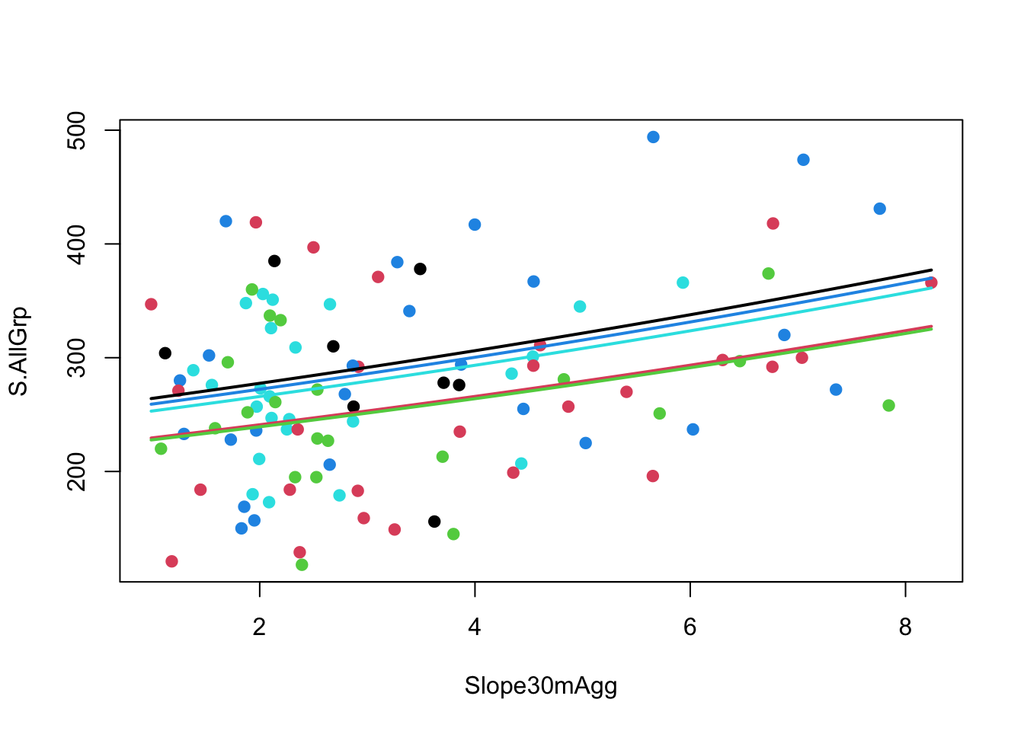

```r
# plot the observed Richness Vs predictor
plot(S.AllGrp~Slope30mAgg,
     data = DK.Biodiv,
     pch = 19,
     col = DK.Biodiv$landsdele)
# Add the predictors per Region
for (i in levels(DK.Biodiv$landsdele)){
  lines(S.AllGrp~Slope30mAgg, # A formula stating the variable to plot and grouping variable
        data = TempPredReg[TempPredReg$landsdele == i,],
        col = which(i==levels(DK.Biodiv$landsdele)),
        lwd=2)
}
```

**Question:** Based on the figure above, is there any difference in the species richness over the different Danish regions?.

Yes, *Midtjylland* and *Nordjylland* will have a lower overall species richness that other parts of Denmark across the range of values for the predictor.

## 6) Setting the Scene for the mixed effect Random slope model

**Your task:**

Use the function `glm()` to build model with the predictor you selected in `DK.Biodiv.lm` AND `landsdele`, as a predictor. Here add the categorical predictors as full interaction term (X_1_ * X_2_). **Remember** to include the adequate `family`for the class of `S.AllGrp`.

```r
DK.Biodiv.lm3 <- glm(S.AllGrp ~ Slope30mAgg * landsdele, #  the Equations defining the response and additive combination of predictors
                    data = DK.Biodiv,
                    family = "poisson")
# Print the summary of DK.Biodiv.lm3
summary(DK.Biodiv.lm3)
```

```
##
## Call:
## glm(formula = S.AllGrp ~ Slope30mAgg * landsdele, family = "poisson",
##     data = DK.Biodiv)
##
## Deviance Residuals:
##     Min       1Q   Median       3Q      Max
## -9.2658  -3.3009  -0.4255   2.5993  10.4846
##
## Coefficients:
##                                  Estimate Std. Error z value Pr(>|z|)
## (Intercept)                       5.94135    0.06815  87.182  < 2e-16 ***
## Slope30mAgg                      -0.09005    0.02268  -3.971 7.16e-05 ***
## landsdeleMidtjylland             -0.56270    0.07322  -7.685 1.52e-14 ***
## landsdeleNordjylland             -0.48304    0.07352  -6.570 5.02e-11 ***
## landsdeleSjælland                -0.52484    0.07256  -7.234 4.70e-13 ***
## landsdeleSyddanmark              -0.44009    0.07460  -5.899 3.66e-09 ***
## Slope30mAgg:landsdeleMidtjylland  0.14058    0.02343   6.000 1.98e-09 ***
## Slope30mAgg:landsdeleNordjylland  0.11491    0.02377   4.834 1.34e-06 ***
## Slope30mAgg:landsdeleSjælland     0.16278    0.02333   6.978 3.00e-12 ***
## Slope30mAgg:landsdeleSyddanmark   0.13358    0.02481   5.383 7.32e-08 ***
## ---
## Signif. codes:  0 '***' 0.001 '**' 0.01 '*' 0.05 '.' 0.1 ' ' 1
##
## (Dispersion parameter for poisson family taken to be 1)
##
##     Null deviance: 2379.7  on 103  degrees of freedom
## Residual deviance: 1990.7  on  94  degrees of freedom
## AIC: 2781.6
##
## Number of Fisher Scoring iterations: 4
```

**Question:** how much has the Model performance improved (i.e., **deviance explained**) by adding the categorical term?.

The model with the categorical term now explains ~16% of the deviance while one with out it explains only 8%

**Question:** how much has adding the categorical term costed in terms of degrees of freedom?.

## 7) Building a random slope model

**Your task:**

- Build a Generalized linear Mixed effects model that includes “region”as random slope For this, use the function `glmer` of the package `lme4`. Remember that in `lme4`, random effects are added defined as `(X2 | X1)`, and added as a predictor in your function.

```r
DK.Biodiv.RndSlope <- glmer(S.AllGrp ~ Slope30mAgg + (Slope30mAgg| landsdele), #  the Equations defining the response and additive combination of predictors
                            data =DK.Biodiv,
                            family = "poisson")
# Print the summary of DK.Biodiv.RndSlope
summary(DK.Biodiv.RndSlope)
```

```
## Generalized linear mixed model fit by maximum likelihood (Laplace
##   Approximation) [glmerMod]
##  Family: poisson  ( log )
## Formula: S.AllGrp ~ Slope30mAgg + (Slope30mAgg | landsdele)
##    Data: DK.Biodiv
##
##      AIC      BIC   logLik deviance df.resid
##   2813.4   2826.6  -1401.7   2803.4       99
##
## Scaled residuals:
##     Min      1Q  Median      3Q     Max
## -8.3570 -3.1729 -0.4414  2.6444 11.5143
##
## Random effects:
##  Groups    Name        Variance Std.Dev. Corr
##  landsdele (Intercept) 0.035470 0.1883
##            Slope30mAgg 0.002715 0.0521   -0.96
## Number of obs: 104, groups:  landsdele, 5
##
## Fixed effects:
##             Estimate Std. Error z value Pr(>|z|)
## (Intercept)  5.53138    0.08614  64.218   <2e-16 ***
## Slope30mAgg  0.02296    0.02396   0.958    0.338
## ---
## Signif. codes:  0 '***' 0.001 '**' 0.01 '*' 0.05 '.' 0.1 ' ' 1
##
## Correlation of Fixed Effects:
##             (Intr)
## Slope30mAgg -0.961
```

**Question:** How did the addition of a random slopes change the parameter estimates in `DK.Biodiv.RndSlope` when compared to those in `DK.Biodiv.lm`?.

The parameters and their SE changed , with the largest change taking place in the slope.

**Question:** how much has the model performance improved (i.e., **deviance explained**) when compared to the original model by adding the regions as a random intercept?.

**Your task:**

- Extract the random intercepts and slopes from the `DK.Biodiv.RndSlope` model. For this, you will use the function `random.effects` of the package `nlme`.

```r
 # Extract the random intercepts
 random.effects(DK.Biodiv.RndSlope)
```

```
## $landsdele
##             (Intercept)  Slope30mAgg
## Hovedstaden  0.36092957 -0.097225058
## Midtjylland -0.14666426  0.026819175
## Nordjylland -0.06894549  0.002018074
## Sjælland    -0.11698592  0.049577907
## Syddanmark  -0.02739397  0.018772756
##
## with conditional variances for "landsdele"
```

**Question:** Make an interpretation of the random slopes extracted in the task above?.

These indicate how much will species richness increase of decrease within a region was a function of the predictors. The values show that in *Hovedstaden* diversity decrease as a function of the predictor.

**Your task:**

- Generate a prediction for your random slope model, taking into consideration the effect of “region” and plot these predictions. For this, you will:
  1. Generate a new object to be used for predicting your model. This new object, named `TempPred` will have 100 values between the minimum and maximum of your selected predictor.
  2. Create a new object names `TempPredReg` where the values in `TempPred` are paired to a sequence of 100 times the string name of each region.
  3. Use `DK.Biodiv.RndInt` to generate a prediction for each predictor/region combination in `TempPredReg`.
  4. Append the predicted values to `TempPredReg` as a variable named `S.AllGrp`.
  5. Plot the **OBSERVED** change in richness (`S.AllGrp`) as a function of the predictor as a scatter plot.
  6. Add a line (using the function `lines()` and the data in `TempPredReg` ) for each of the region specific predictions.

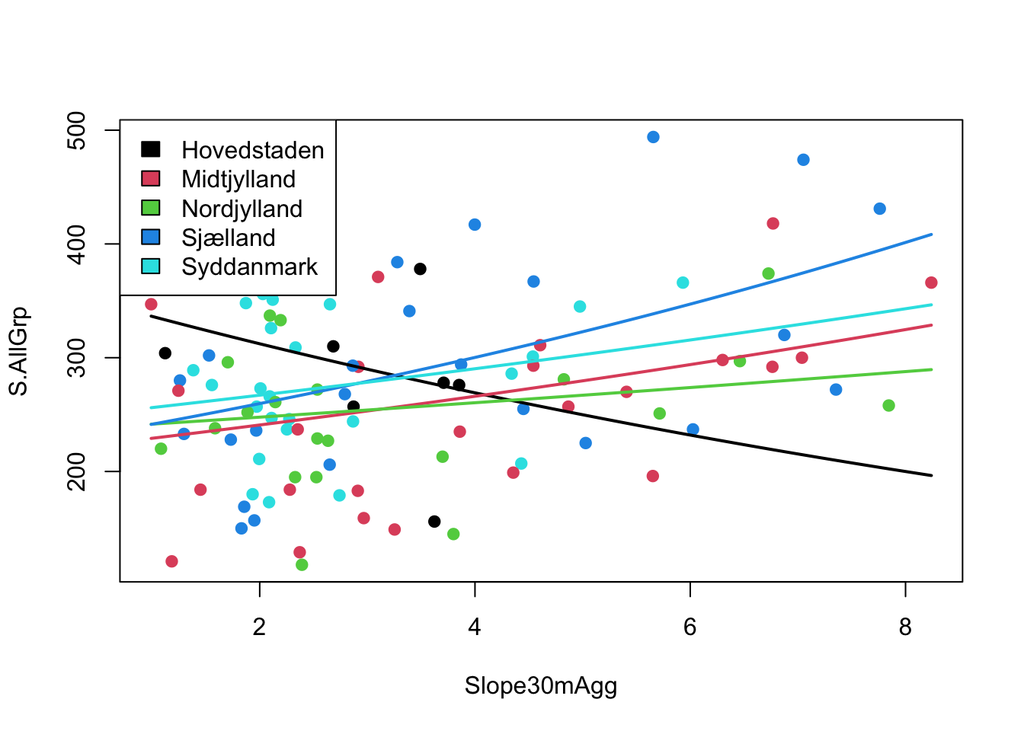

```r
# 1) Generate a new object with sequential values for the predictor.
TempPred <- seq(from = min(DK.Biodiv$Slope30mAgg), # the starting values
                to = max(DK.Biodiv$Slope30mAgg), # the end value
                length.out = 100) # number of object in between

# 2) pair sequential values with regions names
TempPredReg <- data.frame(Slope30mAgg = TempPred, # sequential predictors values
                          landsdele = rep(levels(DK.Biodiv$landsdele), # Values to repeat
                                          each = 100) # number of times
                          )
# 3/4) generate a prediction for each predictor/region combination
TempPredReg$S.AllGrp <- predict(DK.Biodiv.RndSlope, # Model
                                newdata = TempPredReg, # A data frame in which to look for variables with which to predict.
                                type = "response" # the type of prediction required
                                )
# plot the observed Richness Vs predictor
plot(S.AllGrp~Slope30mAgg,
     data = DK.Biodiv,
     pch = 19,
     col = DK.Biodiv$landsdele)
# Add the predictors per Region
for (i in levels(DK.Biodiv$landsdele)){
  lines(S.AllGrp~Slope30mAgg, # A formula stating the variable to plot and grouping variable
        data = TempPredReg[TempPredReg$landsdele == i,],
        col = which(i==levels(DK.Biodiv$landsdele)),
        lwd=2)
}
legend("topleft",
       legend = levels(DK.Biodiv$landsdele),
       fill =1:5)
```

**Question:** Based on the figure above, is there any difference in the species richness over the different Danish regions?. Yes, *Hovedstaden* will have a lower overall higher species richness than any point in Denmark for low values of slope. Also, the changes in richness differers between regions, with *Nordjylland* having the slowest changes,and *Sjælland* the fastest changes.

## 8) Random Intectep or random slope?

**Your task:**

- Evaluate if the model with the random intercept or the random slope is the best model. For this, you will use the functions `anova()` and `AIC()`. Remember that the `anova()` test requires you to define the right test.

```r
# Anova contrasting the random intercept vs slope models
anova(DK.Biodiv.RndInt, # Model 1
      DK.Biodiv.RndSlope,# Model 2
      test = "Chisq") # How to contrast models
```

```
## Data: DK.Biodiv
## Models:
## DK.Biodiv.RndInt: S.AllGrp ~ Slope30mAgg + (1 | landsdele)
## DK.Biodiv.RndSlope: S.AllGrp ~ Slope30mAgg + (Slope30mAgg | landsdele)
##                    npar    AIC    BIC  logLik deviance  Chisq Df Pr(>Chisq)
## DK.Biodiv.RndInt      3 2855.3 2863.2 -1424.7   2849.3
## DK.Biodiv.RndSlope    5 2813.4 2826.6 -1401.7   2803.4 45.913  2  1.072e-10 ***
## ---
## Signif. codes:  0 '***' 0.001 '**' 0.01 '*' 0.05 '.' 0.1 ' ' 1
```

```r
# AIC fo the models
AIC(DK.Biodiv.RndInt, # Model 1
    DK.Biodiv.RndSlope) # Model 2
```

```
##                    df      AIC
## DK.Biodiv.RndInt    3 2855.290
## DK.Biodiv.RndSlope  5 2813.377
```

**Question:** Based on the tests above, which model is best?.

The anova test indicates that the two models are significant different in the explained deviance; and that the Random slope model performs significantly better.

## 10) Now with a GAM.

**Your task:**

- Build a Generalized Additive model that includes “region”as random intercept. For this, use the function `gam` of the package `mgcv`. Here you will add `landsdele` as a smoother type to random effect (`re`).

```r
DK.Biodiv.RndGAM <- gam(S.AllGrp ~ s(Slope30mAgg) + s(landsdele,bs = "re"), #  the Equations defining the response and additive combination of predictors
                           data =DK.Biodiv,
                            family = "poisson")

# Print the summary of DK.Biodiv.RndGAM
summary(DK.Biodiv.RndGAM)
```

```
##
## Family: poisson
## Link function: log
##
## Formula:
## S.AllGrp ~ s(Slope30mAgg) + s(landsdele, bs = "re")
##
## Parametric coefficients:
##             Estimate Std. Error z value Pr(>|z|)
## (Intercept)  5.62643    0.05524   101.9   <2e-16 ***
## ---
## Signif. codes:  0 '***' 0.001 '**' 0.01 '*' 0.05 '.' 0.1 ' ' 1
##
## Approximate significance of smooth terms:
##                  edf Ref.df Chi.sq p-value
## s(Slope30mAgg) 4.312  5.306  284.5  <2e-16 ***
## s(landsdele)   3.941  4.000  121.6  <2e-16 ***
## ---
## Signif. codes:  0 '***' 0.001 '**' 0.01 '*' 0.05 '.' 0.1 ' ' 1
##
## R-sq.(adj) =  0.0943   Deviance explained = 15.8%
## UBRE = 18.443  Scale est. = 1         n = 104
```

**Your task:**

- Generate a prediction for your random intercept GAM, taking into consideration the effect of “region” and plot these predictions. For this, you will:
  1. Generate a new object to be used for predicting your model. This new object, named `TempPred` will have 100 values between the minimum and maximum of your selected predictor.
  2. Create a new object names `TempPredReg` where the values in `TempPred` are paired to a sequence of 100 times the string name of each region.
  3. Use `DK.Biodiv.RndInt` to generate a prediction for each predictor/region combination in `TempPredReg`.
  4. Append the predicted values to `TempPredReg` as a variable named `S.AllGrp`.
  5. Plot the **OBSERVED** change in richness (`S.AllGrp`) as a function of the predictor as a scatter plot.
  6. Add a line (using the function `lines()` and the data in `TempPredReg` ) for each of the region specific predictions.

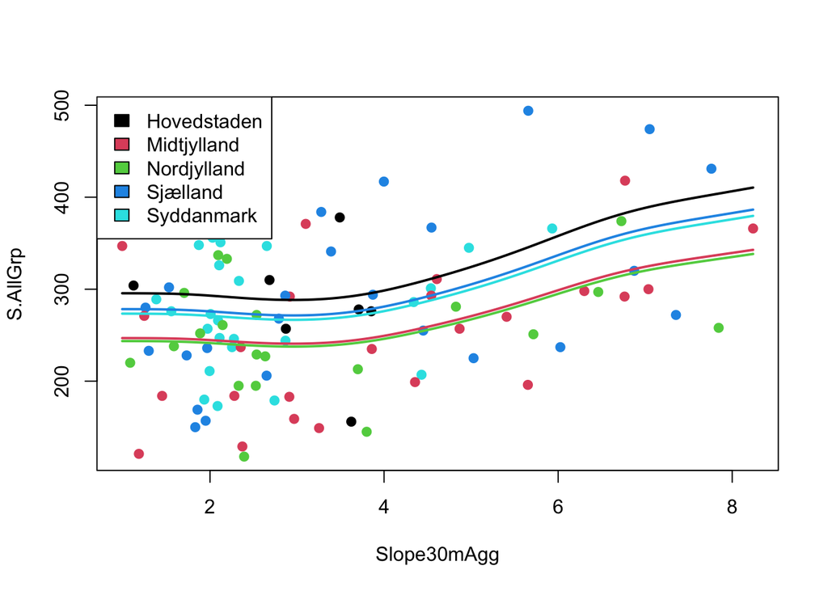

```r
# 1) Generate a new object with sequential values for the predictor.
TempPred <- seq(from = min(DK.Biodiv$Slope30mAgg), # the starting values
                to = max(DK.Biodiv$Slope30mAgg), # the end value
                length.out = 100) # number of object in between

# 2) pair sequential values with regions names
TempPredReg <- data.frame(Slope30mAgg = TempPred, # sequential predictors values
                          landsdele = rep(levels(DK.Biodiv$landsdele), # Values to repeat
                                          each = 100) # number of times
                          )
# 3/4) generate a prediction for each predictor/region combination
TempPredReg$S.AllGrp <- predict(DK.Biodiv.RndGAM, # Model
                                newdata = TempPredReg, # A data frame in which to look for variables with which to predict.
                                type = "response" # the type of prediction required
                                )
# plot the observed Richness Vs predictor
plot(S.AllGrp~Slope30mAgg,
     data = DK.Biodiv,
     pch = 19,
     col = DK.Biodiv$landsdele)
# Add the predictors per Region
for (i in levels(DK.Biodiv$landsdele)){
  lines(S.AllGrp~Slope30mAgg, # A formula stating the variable to plot and grouping variable
        data = TempPredReg[TempPredReg$landsdele == i,],
        col = which(i==levels(DK.Biodiv$landsdele)),
        lwd=2)
}
legend("topleft",
       legend = levels(DK.Biodiv$landsdele),
       fill =1:5)
```

**Your task:**

- Build a Generalized Additive model that includes in your smoother both the predictor and “region”as random factor. For this, use the function `gam` of the package `mgcv`. Here you will add `landsdele` as a smoother type to random effect (`re`) and model the Predictor-region interaction as a Tensor product smooth (`te(X, Z, bs = c("A","B"))`).

```r
DK.Biodiv.RndGAM2 <- gam(S.AllGrp ~ te(Slope30mAgg, landsdele,bs = c("cr","re")), #  the Equations defining the response and additive combination of predictors
                           data =DK.Biodiv,
                            family = "poisson")

# Print the summary of DK.Biodiv.RndGAM
summary(DK.Biodiv.RndGAM2)
```

```
##
## Family: poisson
## Link function: log
##
## Formula:
## S.AllGrp ~ te(Slope30mAgg, landsdele, bs = c("cr", "re"))
##
## Parametric coefficients:
##             Estimate Std. Error z value Pr(>|z|)
## (Intercept)   5.6607     0.1461   38.74   <2e-16 ***
## ---
## Signif. codes:  0 '***' 0.001 '**' 0.01 '*' 0.05 '.' 0.1 ' ' 1
##
## Approximate significance of smooth terms:
##                             edf Ref.df Chi.sq p-value
## te(Slope30mAgg,landsdele) 22.54     24  674.3  <2e-16 ***
## ---
## Signif. codes:  0 '***' 0.001 '**' 0.01 '*' 0.05 '.' 0.1 ' ' 1
##
## R-sq.(adj) =  0.0971   Deviance explained = 28.6%
## UBRE = 15.783  Scale est. = 1         n = 104
```

**Your task:**

- Generate a prediction for your random slope GAM, taking into consideration the effect of “region” and plot these predictions. For this, you will:
  1. Generate a new object to be used for predicting your model. This new object, named `TempPred` will have 100 values between the minimum and maximum of your selected predictor.
  2. Create a new object names `TempPredReg` where the values in `TempPred` are paired to a sequence of 100 times the string name of each region.
  3. Use `DK.Biodiv.RndInt` to generate a prediction for each predictor/region combination in `TempPredReg`.
  4. Append the predicted values to `TempPredReg` as a variable named `S.AllGrp`.
  5. Plot the **OBSERVED** change in richness (`S.AllGrp`) as a function of the predictor as a scatter plot.
  6. Add a line (using the function `lines()` and the data in `TempPredReg` ) for each of the region specific predictions.

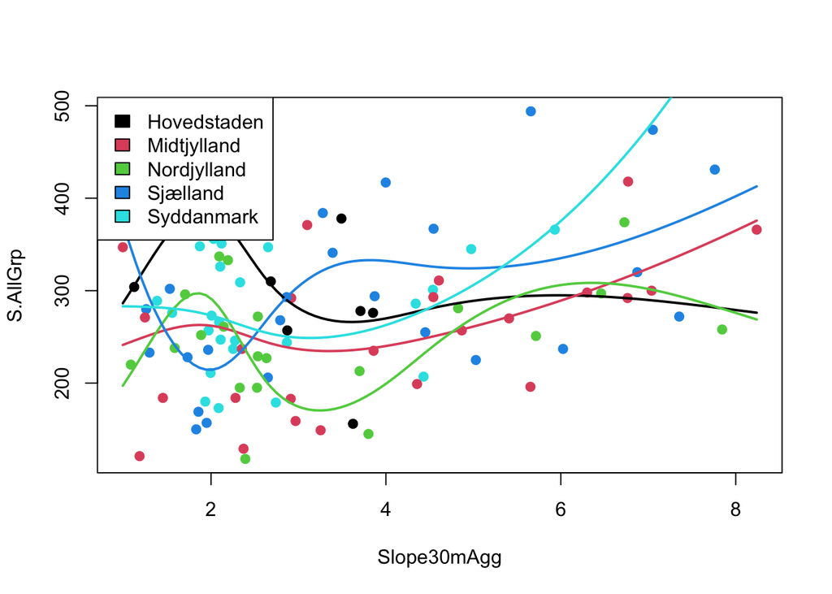

```r
# 1) Generate a new object with sequential values for the predictor.
TempPred <- seq(from = min(DK.Biodiv$Slope30mAgg), # the starting values
                to = max(DK.Biodiv$Slope30mAgg), # the end value
                length.out = 100) # number of object in between

# 2) pair sequential values with regions names
TempPredReg <- data.frame(Slope30mAgg = TempPred, # sequential predictors values
                          landsdele = rep(levels(DK.Biodiv$landsdele), # Values to repeat
                                          each = 100) # number of times
                          )
# 3/4) generate a prediction for each predictor/region combination
TempPredReg$S.AllGrp <- predict(DK.Biodiv.RndGAM2, # Model
                                newdata = TempPredReg, # A data frame in which to look for variables with which to predict.
                                type = "response" # the type of prediction required
                                )
# plot the observed Richness Vs predictor
plot(S.AllGrp~Slope30mAgg,
     data = DK.Biodiv,
     pch = 19,
     col = DK.Biodiv$landsdele)
# Add the predictors per Region
for (i in levels(DK.Biodiv$landsdele)){
  lines(S.AllGrp~Slope30mAgg, # A formula stating the variable to plot and grouping variable
        data = TempPredReg[TempPredReg$landsdele == i,],
        col = which(i==levels(DK.Biodiv$landsdele)),
        lwd=2)
}
legend("topleft",
       legend = levels(DK.Biodiv$landsdele),
       fill =1:5)
```